# slide_deck_template slides

[figure not shown]

> An airplane or aeroplane (informally plane) is a powered, fixed-wing aircraft that is propelled forward by thrust from a jet engine, propeller or rocket engine. Airplanes come in a variety of sizes, shapes, and wing configurations. The broad spectrum of uses for airplanes includes recreation, transportation of goods and people, military, and research. Worldwide, commercial aviation transports more than four billion passengers annually on airliners[1] and transports more than 200 billion tonne-kilometers[2] of cargo annually, which is less than 1% of the world's cargo movement.[3] Most airplanes are flown by a pilot on board the aircraft, but some are designed to be remotely or computer-controlled such as drones.

```python
data.head(2)
```

|  | tailnum | type | manufacturer | issue_date | model | status | aircraft_type | engine_type | year |
| --- | --- | --- | --- | --- | --- | --- | --- | --- | --- |
| 34 | N10156 | Corporation | EMBRAER | 02/13/2004 | EMB-145XR | Valid | Fixed Wing Multi-Engine | Turbo-Fan | 2004 |
| 35 | N102UW | Corporation | AIRBUS INDUSTRIE | 05/26/1999 | A320-214 | Valid | Fixed Wing Multi-Engine | Turbo-Fan | 1998 |

[figure not shown]

# A - for " years - months ":

## 1) How will the data for the years be analyzed ?

```python
all_years
```

|  | years | counts |
| --- | --- | --- |
| 27 | 1976 | 1 |
| 26 | 1978 | 1 |
| 25 | 1984 | 2 |
| 24 | 1985 | 33 |
| 20 | 1986 | 74 |
| 23 | 1987 | 52 |
| 21 | 1988 | 70 |
| 17 | 1989 | 82 |
| 18 | 1990 | 80 |
| 15 | 1991 | 99 |
| 14 | 1992 | 101 |
| 22 | 1993 | 66 |
| 19 | 1994 | 75 |
| 16 | 1995 | 84 |
| 12 | 1996 | 108 |
| 11 | 1997 | 133 |
| 10 | 1998 | 239 |
| 8 | 1999 | 297 |
| 6 | 2000 | 311 |
| 4 | 2001 | 332 |
| 7 | 2002 | 305 |
| 5 | 2003 | 318 |
| 1 | 2004 | 454 |
| 3 | 2005 | 334 |
| 9 | 2006 | 245 |
| 2 | 2007 | 335 |
| 13 | 2008 | 101 |

### Note that the years span from 1976 to 2008

I will study it in general first, then for a more careful study I will divide the time period 1976-2008 into two parts:

1) Before 1/1/2000

## 2) What are the years in which the number of trips increased ?

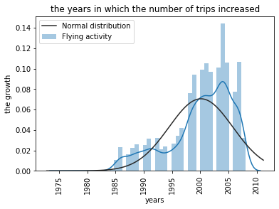

```python
# A visualization of the flight activity over all the years
sns.distplot(data_archive.years ,fit=norm );
plt.legend(['Normal distribution','Flying activity'])
plt.title('the years in which the number of trips increased')
plt.xlabel('years')
plt.xticks(rotation = 90)
plt.ylabel('the growth')
```

## Conclusions in general :

1) We note that the trips began in 1976

2) Data recorded from 1976 to 2008

3) The most active year in air travel is 2004, when 454 different flights were witnessed

4) Compared to the years of the millennium, 1999 and 1998 were good years with significant air traffic activity

5) Relative to the increase in the aviation industry, we notice a direct change in the number of years and an increase in flights.

6) The percentage of activity witnessed in 2004 = 10%, and it was an increase of 3% over the year 2007

## 3) In the 1990s and 1980s, what years did you record a large number of flights?

In general, the graphic display shows the most active year, as the year [1991,1992] witnessed good activity in the flights, then the flights decreased during the period 1993-1995 and increased positively again.

The year 1999 was the most active year, reaching 18%, a difference of 4% from 1998, and 1989 was one of the good years and its activity was remarkable, i.e. 80'S , as it witnessed activity with an increase of 1% over 1994 , 90's , although the difference in years Between the two periods equals 3 years

## 4) What are the most effective months for trips?

```python
month_years_90=pd.DataFrame({'month_years':['1999-Dec',
'1998-Jul',
'1986-Dec',
'1998-Dec',
'1999-Sep',
'1999-Jun',
'1999-Aug',
'1998-Jun',
'1999-Jan',
'1998-Oct',
'1998-Feb',
'1996-Jul',
'1999-May',
'1999-Mar',
'1992-Jun',
'1999-Oct',
'1998-Sep',
'1998-May',
'1991-Jul',
'1999-Nov'],

'counts':[53,
39,
38,
36,
36,
30,
28,
24,
24,
22,
21,
21,
20,
20,
19,
19,
19,
18,
18,
18]},
index=[1,2,3,4,5,6,7,8,9,10,11,12,13,14,15,16,17,18,19,20] )

month_years_90
```

|  | month_years | counts |
| --- | --- | --- |
| 1 | 1999-Dec | 53 |
| 2 | 1998-Jul | 39 |
| 3 | 1986-Dec | 38 |
| 4 | 1998-Dec | 36 |
| 5 | 1999-Sep | 36 |
| 6 | 1999-Jun | 30 |
| 7 | 1999-Aug | 28 |
| 8 | 1998-Jun | 24 |
| 9 | 1999-Jan | 24 |
| 10 | 1998-Oct | 22 |
| 11 | 1998-Feb | 21 |
| 12 | 1996-Jul | 21 |
| 13 | 1999-May | 20 |
| 14 | 1999-Mar | 20 |
| 15 | 1992-Jun | 19 |
| 16 | 1999-Oct | 19 |
| 17 | 1998-Sep | 19 |
| 18 | 1998-May | 18 |
| 19 | 1991-Jul | 18 |
| 20 | 1999-Nov | 18 |

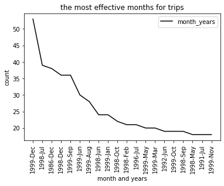

```python
a=month_years_90.month_years
b=month_years_90.counts



plt.plot(a,b,'k')

plt.legend(['month_years','counts'])
plt.title('the most effective months for trips')
plt.xlabel('month and years')
plt.xticks(rotation = 90)
plt.ylabel('count')

plt.show()
```

For more in-depth study, we will explore the months, and note through the graph that November 1999 is the lowest month for flights

On the other hand, December 1999 was the month that witnessed the largest increase in flight activity, with approximately 53 flights for different airlines, and July of 1998 was in second place if it contained 39 flights for various airlines, We note here that the difference = 14 flights. The increase is recorded here for the month of December 1999 December 1986 also witnessed excellent activity, if it recorded 38 flights, which is considered a very good number since it is in 80's

# after 1/1/2000 :

```python
after_2000=data_archive.loc[data_archive['years'] > '1999' ,['years','month_years','tailnum','manufacturer',
                                     'model','type','engine_type','aircraft_type','status']].sort_values('years')
after_2000
```

|  | years | month_years | tailnum | manufacturer | model | type | engine_type | aircraft_type | status |
| --- | --- | --- | --- | --- | --- | --- | --- | --- | --- |
| 4081 | 2000 | 2000-Dec | N825MH | BOEING | 767-432ER | Corporation | Turbo-Jet | Fixed Wing Multi-Engine | Valid |
| 3732 | 2000 | 2000-Nov | N77258 | BOEING | 737-824 | Corporation | Turbo-Fan | Fixed Wing Multi-Engine | Valid |
| 3742 | 2000 | 2000-Aug | N772SW | BOEING | 737-7H4 | Corporation | Turbo-Fan | Fixed Wing Multi-Engine | Valid |
| 3746 | 2000 | 2000-Jul | N77331 | BOMBARDIER INC | CL-600-2B19 | Corporation | Turbo-Fan | Fixed Wing Multi-Engine | Valid |
| 2147 | 2000 | 2000-Mar | N503SW | BOEING | 737-5H4 | Corporation | Turbo-Jet | Fixed Wing Multi-Engine | Valid |
| ... | ... | ... | ... | ... | ... | ... | ... | ... | ... |
| 1459 | 2008 | 2008-Jun | N378AA | CESSNA | 172E | Individual | Reciprocating | Fixed Wing Single-Engine | Valid |
| 4572 | 2008 | 2008-May | N916WN | BOEING | 737-7H4 | Corporation | Turbo-Fan | Fixed Wing Multi-Engine | Valid |
| 1404 | 2008 | 2008-Mar | N37419 | BOEING | 737-924ER | Corporation | Turbo-Fan | Fixed Wing Multi-Engine | Valid |
| 1340 | 2008 | 2008-Jan | N368CA | BOMBARDIER INC | CL-600-2C10 | Corporation | Turbo-Fan | Fixed Wing Multi-Engine | Valid |
| 5027 | 2008 | 2008-Jul | N999CA | CANADAIR | CL-600-2B19 | Foreign Corporation | Turbo-Jet | Fixed Wing Multi-Engine | Valid |

2735 rows × 9 columns

## 5) What are the years that recorded the highest record after 1/1/2000 ?

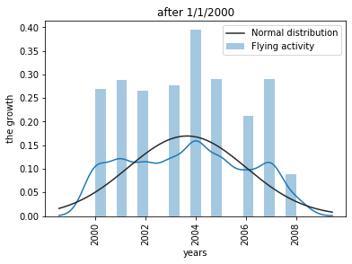

```python
from scipy.stats import norm
sns.distplot(after_2000.years, fit=norm );
plt.legend(['Normal distribution','Flying activity'])
plt.title('after 1/1/2000')
plt.xlabel('years')
plt.xticks(rotation = 90)
plt.ylabel('the growth')
```

It is clear that the new millennium years began with high inflation in the airline industry, there is a high jump starting in 2001, which witnessed 332 different flights. And the year that contain a high record in air travel is the year 2004, when 454 different flights were monitored.

## 6) What are the months affected the most by the aviation industry?

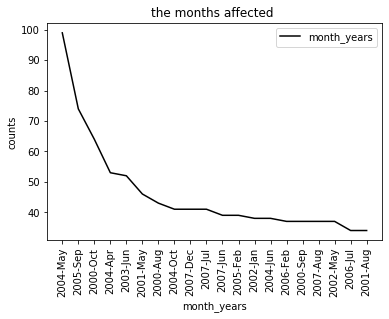

```python
a=most_month.month
b=most_month.counts



plt.plot(a,b,'k')

plt.legend(['month_years','counts'])
plt.title('the months affected ')
plt.xlabel('month_years')
plt.xticks(rotation = 90)
plt.ylabel('counts')

plt.show()
```

We note the air industrial jump that occurred in the new millennium, it is clear that there is growth in the aviation industry, as the month of May of 2004 recorded a high record of flights, 99 flights for various airlines While 74 flights were recorded in September of 2005, that is, there is a difference of 25 flights in the record of May of 2004, "I expect that there was an occasion in that month."

We also note that over 8 months, there has been a noticeable flight activity, which is months in a period extending from 2000-2005 = 429

## 7) What is the conclusion and perception of the increase in the number of years and the number of trips during the mentioned period ?

> Aviation is one of the most “global” industries: connecting people, cultures and businesses across continents. Colleagues throughout the sector are committed to raising awareness of the benefits and the role of aviation. It is necessary for all stakeholders and partners to work together to maximize the benefits of air transport, and to support the sustainable growth of aviation by connecting more people and more places, more often.

Aviation has continued to expand. It has weathered crises and demonstrated long-term resilience, becoming an indispensable means of transport. Historically, air transport has doubled in size every 15 years and has grown faster than most other industries. In 2016, airlines worldwide carried around 3.8 billion passengers annually with 7.1 trillion revenue passenger kilometres (RPKs). Fifty three million tonnes of freight were transported by air, reaching 205 billion freight tonne kilometres (FTKs). Every day, around 100,000 flights transport over 10 million passengers and around USD18 billion worth of goods.

# B- The manufacturer's

[figure not shown]

## 1) What are the most powerful companies in the aviation industry?

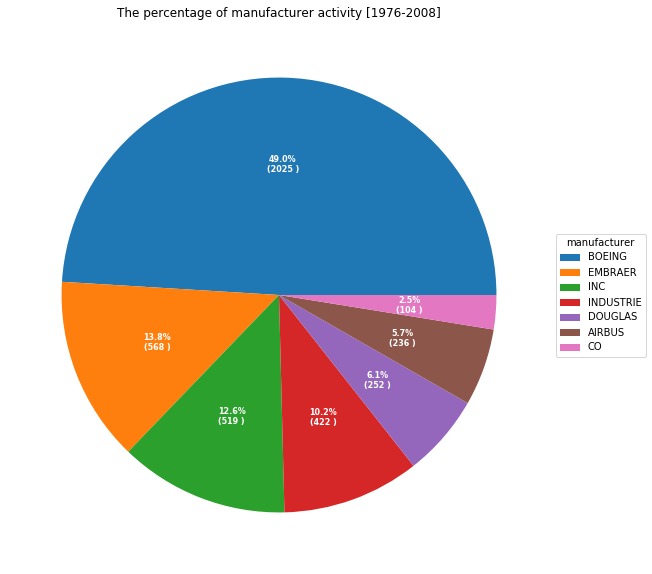

```python
fig, ax = plt.subplots(figsize=(15, 10), subplot_kw=dict(aspect="equal"))

recipe = [
'2025 BOEING',
'569 EMBRAER',
'520 BOMBARDIER INC',
'422 AIRBUS INDUSTRIE',
'252 MCDONNELL DOUGLAS',
'237 AIRBUS',
'105  MCDONNELL DOUGLAS AIRCRAFT CO',
]

data = [float(x.split()[0]) for x in recipe]
ingredients = [x.split()[-1] for x in recipe]


def func(pct, allvals):
    absolute = int(pct/100.*np.sum(allvals))
    return "{:.1f}%\n({:d} )".format(pct, absolute)

plt.xticks(rotation = 90);
wedges, texts, autotexts = ax.pie(data, autopct=lambda pct: func(pct, data),
                                  textprops=dict(color="w"))

ax.legend(wedges, ingredients,
          title="manufacturer",
          loc="center left",
          bbox_to_anchor=(1, 0, 0.5, 1))

plt.setp(autotexts, size=8, weight="bold")

ax.set_title("The percentage of manufacturer activity [1976-2008]")

plt.show()
```

At the level of the two decades, the most active company is BOEING, where there are about 2025 in its records, starting from 1984-2008, which is a total of 49% of all the remaining flights for the different companies in that period of time.

In second place is EMBRAER, with a rate of 14%, it recorded 568 different flights in its balance from 1993 to 2008.

## 2) What were the manufacturer's statistics before 1/1/2000?

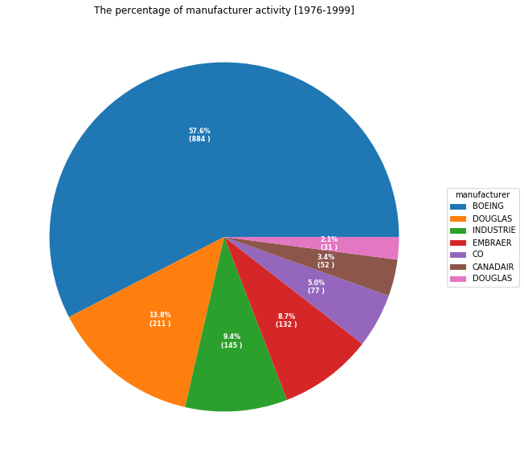

```python
fig, ax = plt.subplots(figsize=(15, 10), subplot_kw=dict(aspect="equal"))

recipe = ['884  BOEING ',
'212  MCDONNELL DOUGLAS',
'145 AIRBUS INDUSTRIE ',
'133 EMBRAER ',
'77 MCDONNELL DOUGLAS AIRCRAFT CO',
'52 CANADAIR',
'32 DOUGLAS'
 ]

data = [float(x.split()[0]) for x in recipe]
ingredients = [x.split()[-1] for x in recipe]


def func(pct, allvals):
    absolute = int(pct/100.*np.sum(allvals))
    return "{:.1f}%\n({:d} )".format(pct, absolute)

plt.xticks(rotation = 90);
wedges, texts, autotexts = ax.pie(data, autopct=lambda pct: func(pct, data),
                                  textprops=dict(color="w"))

ax.legend(wedges, ingredients,
          title="manufacturer",
          loc="center left",
          bbox_to_anchor=(1, 0, 0.5, 1))

plt.setp(autotexts, size=8, weight="bold")

ax.set_title("The percentage of manufacturer activity [1976-1999]")

plt.show()
```

Pre-2000, The most effective company in the aviation industry is the rising company BOEING, with a 58% rate and 884 different flights

With a difference of 672 flights from the first place and by 14%, MCDONNELL DOUGLAS ranks second with a score of 212 different flights,

## 3) What are the manufacturer's statistics after 1/1/2000?

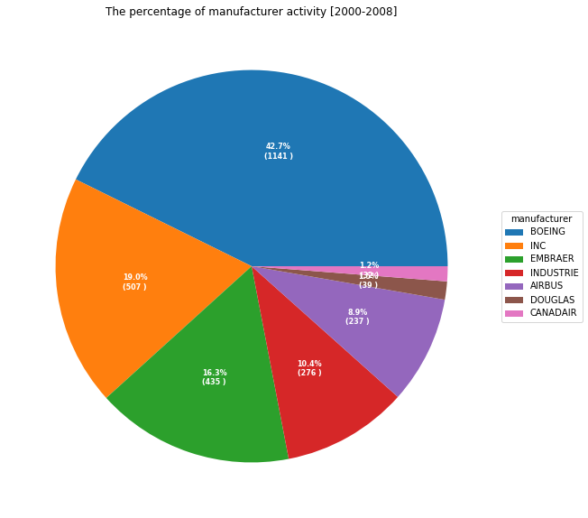

```python
fig, ax = plt.subplots(figsize=(15, 10), subplot_kw=dict(aspect="equal"))

recipe = ['1141  BOEING',
'508  BOMBARDIER INC',
'436  EMBRAER',
'277  AIRBUS INDUSTRIE',
'237  AIRBUS',
'40  MCDONNELL DOUGLAS',
'33  CANADAIR'
 ]

data = [float(x.split()[0]) for x in recipe]
ingredients = [x.split()[-1] for x in recipe]


def func(pct, allvals):
    absolute = int(pct/100.*np.sum(allvals))
    return "{:.1f}%\n({:d} )".format(pct, absolute)

plt.xticks(rotation = 90);
wedges, texts, autotexts = ax.pie(data, autopct=lambda pct: func(pct, data),
                                  textprops=dict(color="w"))

ax.legend(wedges, ingredients,
          title="manufacturer",
          loc="center left",
          bbox_to_anchor=(1, 0, 0.5, 1))

plt.setp(autotexts, size=8, weight="bold")

ax.set_title("The percentage of manufacturer activity [2000-2008]")

plt.show()
```

After 2000 We notice the great leap of BOEING as it moved to record 1141 flights in massive activity in just 8 years after 2000, a great industry and this is 43%

Also in the second most powerful airline, BOMBARDIER INC if it has 19% of the operational percentage, i.e. an average of 507 different flights

In third place, with 16% operating rate, the airline EMBRAER had 435 different flights

## 4) Based on the statistics, what are the expectations of increased growth between companies?

1) It is clear that BOEING has a high growth rate during the coming years, as we note that it has a growth rate in the years after 1/1/2000 estimated at 26% and that something from an economic and industrial point of view is very appropriate.

2) BOMBARDIER INC is a very strong and growing company in the aviation industry, with a growth rate of 12% company-wide

3) The third company with a growth of 10% is EMBRAER

# C- The Model :

[figure not shown]

## 2)What are the models most used in the aviation industry?

```python
most_model=pd.DataFrame(
{'model':['CL-600-2B19',
'737-7H4',
'A320-232',
'EMB-145LR',
'CL-600-2C10',
'737-3H4',
'DC-9-82(MD-82)',
'MD-88',
'757-232',
'EMB-145XR']
,

'counts':[383,
298,
236,
213,
156,
147,
142,
117,
111,
104]},

index=[1,2,3,4,5,6,7,8,9,10] )

most_model
```

|  | model | counts |
| --- | --- | --- |
| 1 | CL-600-2B19 | 383 |
| 2 | 737-7H4 | 298 |
| 3 | A320-232 | 236 |
| 4 | EMB-145LR | 213 |
| 5 | CL-600-2C10 | 156 |
| 6 | 737-3H4 | 147 |
| 7 | DC-9-82(MD-82) | 142 |
| 8 | MD-88 | 117 |
| 9 | 757-232 | 111 |
| 10 | EMB-145XR | 104 |

## 3) What are the models that were relied upon before 1/1/2000?

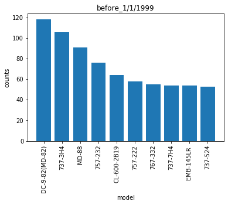

```python
x =[

'DC-9-82(MD-82)',
'737-3H4',
'MD-88',
'757-232',
'CL-600-2B19',
'757-222',
'767-332',
'737-7H4',
'EMB-145LR ',
'737-524']


y = [118,
106,
91,
76,
64,
58,
55,
54,
54,
53]



plt.bar(x,y)
plt.xlabel("model")
plt.ylabel('counts')
plt.title('before_1/1/1999')
plt.xticks(rotation = 90);

plt.show()
```

## Before 1/1/2000

1) The aviation industry has been heavily dependent on the DC-9-82 (MD-82), 118 aircraft

2) The second most common model is the 737-3H4, which was applied to 106 aircraft

3) The third most common model is the MD-88, which has been applied to 91 different aircraft

## What are the models adopted in the aviation industry after 1/1/2000?

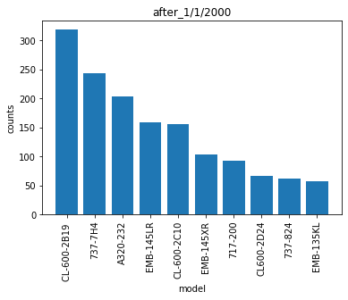

```python
x = ['CL-600-2B19 ',
'737-7H4',
'A320-232',
'EMB-145LR',
'CL-600-2C10',
'EMB-145XR',
'717-200',
'CL600-2D24',
'737-824',
'EMB-135KL'
]
y = [319,
244,
204,
159,
156,
104,
93,
66,
62,
58]
#تغير لون محدد في البارت شارت

#نضع c هنا
plt.bar(x,y)
plt.xlabel("model")
plt.ylabel('counts')
plt.title('after_1/1/2000')
plt.xticks(rotation = 90);

plt.show()
```

## After 1/1/2000 :

1) The most common model is the CL-600-2B19, it has been applied to 319 aircraft

2) In second place the 737-7H4 model, it was applied to 244 aircraft

3) In third place, the A320-232 model was applied to 204 aircraft

# Perceptions:

We must note that the model industry has been greatly affected by the progress of the years and the development of technology and heavy engines, so it cannot be judged at all that the models in the years 2000 are the best or that the models in the time of the 90's were ok! Science has advanced and technology has evolved a lot after the millennium years, so it is not fair to compare which is better now because models are not static. They have changed with the change of years.

# D- Type :

[figure not shown]

# corporation:

A corporation is an organization—usually a group of people or a company—authorized by the state to act as a single entity (a legal entity; a legal person in legal context) and recognized as such in law for certain purposes

# Foreign corporation

Foreign corporation is a term used in the United States to describe an existing corporation (or other type of corporate entity, such as a limited liability company or LLC) that conducts business in a state or jurisdiction other than where it was originally incorporated.[1] The term applies both to domestic corporations that are incorporated in another state and to corporations that are incorporated in a nation other than the United States. All states require that foreign corporations register with the state before conducting business in the state.[2]

# Co-ownership

Co-ownership is a legal concept in a business where two or more co-owners share the legal ownership of property.

# Partnership

A partnership is an arrangement where parties, known as business partners, agree to cooperate to advance their mutual interests. The partners in a partnership may be individuals, businesses, interest-based organizations, schools, governments or combinations. Organizations may partner to increase the likelihood of each achieving their mission and to amplify their reach. A partnership may result in issuing and holding equity or may be only governed by a contract.

## 1) What was the most popular type 1976-2008?

| Corporation | Individual | Foreign Corporation | Co-Owner | Partnership |
| --- | --- | --- | --- | --- |
| 4397 | 19 | 10 | 5 | 1 |

## 2) What is the most common type 1976-2000?

| Corporation | Individual | Co-Owner | Partnership |
| --- | --- | --- | --- |
| 1580 | 13 | 10 | 4 |

| Corporation | Individual | Foreign Corporation | Co-Owner | Partnership |
| --- | --- | --- | --- | --- |
| 2717 | 6 | 10 | 1 | 1 |

# Perceptions:

We note that it is natural that the corporation is the most common type because it serves a very large category and is effective for government, private, commercial or industrial operations.

## 4) What are the strongest manufacturers of the Corporation type ?!

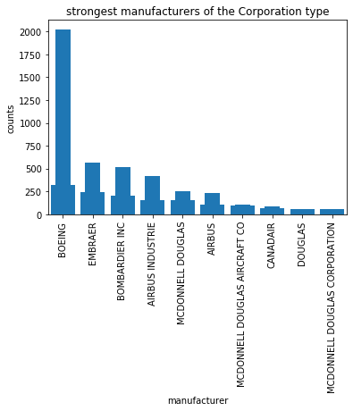

```python
Corporation['manufacturer'].value_counts().head(10).plot.bar()
plt.bar(x,y)
plt.xlabel("manufacturer")
plt.ylabel('counts')

plt.title('strongest manufacturers of the Corporation type');
```

## Conclusions:

1) One of the emerging and successful veteran companies is BOEING, 2023 was recorded in its balance, based on current data, 47% of trips belong to BOEING

2) The second largest airline is EMBRAER with 13% of total flights, with a class of 569

3) The third largest airline is BOMBARDIER INC with 12%, with a score of 517

## 5) What are the strongest manufacturers of the Individual type ?!

[figure not shown]

```python
Individual['manufacturer'].value_counts().head(10).plot.bar();
plt.bar(x,y)
plt.xlabel("manufacturer")
plt.ylabel('counts')
plt.title('strongest manufacturers of the Individual type');
```

## Conclusions:

# E- Engine Type :

[figure not shown]

## 1) What are the most popular types of engines 1976-2008?

| Turbo-Fan | Turbo-Jet | Turbo-Prop | Reciprocating | 4 Cycle | Turbo-Shaft |
| --- | --- | --- | --- | --- | --- |
| 2798 | 1410 | 89 | 28 | 4 | 3 |

# Turbo-Fan:

The turbofan or fanjet is a type of airbreathing jet engine that is widely used in aircraft propulsion. The word "turbofan" is a portmanteau of "turbine" and "fan": the turbo portion refers to a gas turbine engine which achieves mechanical energy from combustion,[1] and the fan, a ducted fan that uses the mechanical energy from the gas turbine to accelerate air rearwards. Thus, whereas all the air taken in by a turbojet passes through the turbine (through the combustion chamber), in a turbofan some of that air bypasses the turbine. A turbofan thus can be thought of as a turbojet being used to drive a ducted fan, with both of these contributing to the thrust.

# Turbo-Jet

The turbojet is an airbreathing jet engine, typically used in aircraft. It consists of a gas turbine with a propelling nozzle. The gas turbine has an air inlet, a compressor, a combustion chamber, and a turbine (that drives the compressor). The compressed air from the compressor is heated by burning fuel in the combustion chamber and then allowed to expand through the turbine. The turbine exhaust is then expanded in the propelling nozzle where it is accelerated to high speed to provide thrust.[1] Two engineers, Frank Whittle in the United Kingdom and Hans von Ohain in Germany, developed the concept independently into practical engines during the late 1930s.

# Turbo-Prop

A turboprop engine is a turbine engine that drives an aircraft propeller.[1]

In its simplest form a turboprop consists of an intake, compressor, combustor, turbine, and a propelling nozzle.[2] Air is drawn into the intake and compressed by the compressor. Fuel is then added to the compressed air in the combustor, where the fuel-air mixture then combusts. The hot combustion gases expand through the turbine. Some of the power generated by the turbine is used to drive the compressor. Thrust is obtained by the combusting gases, pushing toward a (vectored) surface in front of the expanding gas.

The rest is transmitted through the reduction gearing to the propeller. Further expansion of the gases occurs in the propelling nozzle, where the gases exhaust to atmospheric pressure. The propelling nozzle provides a relatively small proportion of the thrust generated by a turboprop.[3]

In contrast to a turbojet, the engine's exhaust gases do not generally contain enough energy to create significant thrust, since almost all of the engine's power is used to drive the propeller.

## 2) What types of engines were used in 1976-2000?

| Turbo-Fan | Turbo-Jet | Turbo-Prop | Reciprocating | 4 Cycle | Turbo-Shaft |
| --- | --- | --- | --- | --- | --- |
| 864 | 655 | 57 | 19 | 2 | 0 |

| Turbo-Fan | Turbo-Jet | Turbo-Prop | Reciprocating | 4 Cycle | Turbo-Shaft |
| --- | --- | --- | --- | --- | --- |
| 1934 | 755 | 32 | 9 | 2 | 3 |

### 3) Comparison of Demand for Engine Types in the "Pre-2000 and Post-2000" Periods :

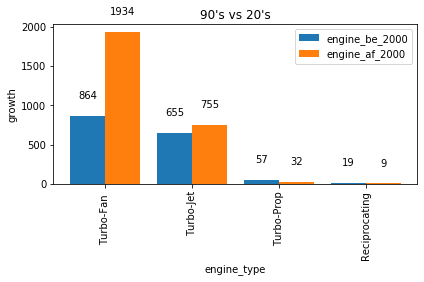

```python
a = ['Turbo-Fan ', 'Turbo-Jet', 'Turbo-Prop', 'Reciprocating']
engine_be_2000 = [ 864 , 655 , 57 ,19 ]
engine_af_2000=[ 1934 ,755, 32, 9]

x = np.arange(len(a))
width = 0.40

fig, ax = plt.subplots()
rects1 = ax.bar(x - width/2, engine_be_2000, width, label='engine_be_2000')
rects2 = ax.bar(x + width/2, engine_af_2000, width, label='engine_af_2000')

ax.set_xlabel('engine_type')
ax.set_ylabel('growth')
ax.set_title("90's vs 20's")
ax.set_xticks(x)
ax.set_xticklabels(a)
ax.legend()


def autolabel(rects):
    for rect in rects:
        height = rect.get_height()
        ax.annotate('{}'.format(height),
                    xy=(rect.get_x() + rect.get_width() / 2, height),
                    xytext=(0,15),
                    textcoords="offset points",
                    ha='center', va='bottom')

plt.xticks(rotation = 90);

autolabel(rects1)
autolabel(rects2)
fig.tight_layout()
fontsize = 40
plt.show()
```

# Conclusions:

## From 1976 to 2008

1) Turbo-Fan is the most common type of motor used for various trips If 2798 aircraft are registered operating on this model

2) In second place were registered 1,410 aircraft powered by Turbo-Jet engine

3) The Turbo-Prop works on 89 different aircraft

## Before 2000:

1) The Turbo-Fan Engine Industry was in the lead, 864 aircraft were registered operating on this engine

2) In second place was the Turbo-Jet engine, 655 different aircraft that were powered by the Turbo-Jet engine

3) In third place was the Turbo-Prop engine, on which 57 aircraft were based The rest is like what is mentioned in the table

## After 2000:

1) In the first place in the aircraft engine industry was the Turbo-Fan, which was based on 1934 different aircraft

2) In second place was the Turbo-Jet engine, which was used in 755 aircraft

## Perceptions:

1) We notice from the graphical visualization the industrial jump in the engine industry in the period before the year 2000 and after the year 2000,

3)There is a 17% increase in demand for the Turbo-Jet engine

4) 0,8% downturn in Turbo-Prop engine demand

5) 0,2% downturn in Reciprocating engine demand

# F- Manufacturer BOEING :

[figure not shown]

Boeing was founded by William Boeing in Seattle, Washington on July 15, 1916.[9] The present corporation is the result of the merger of Boeing with McDonnell Douglas on August 1, 1997. Then chairman and CEO of Boeing, Philip M. Condit, assumed those roles in the combined company, while Harry Stonecipher, former CEO of McDonnell Douglas, became president and COO.[9]

## 2) What is the growth of the company ?! Is it a positive or negative relationship ?

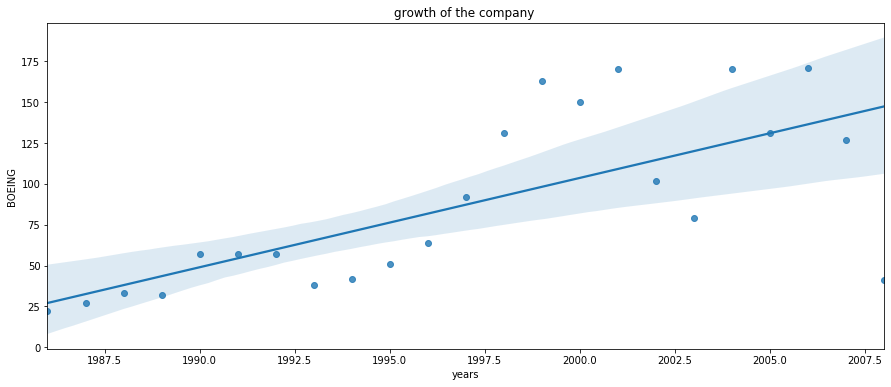

```python
plt.figure(figsize=[15,6])
sns.regplot(data = manufacturer_BOEING,
            x = [2006,2004,2001,1999,2000,2005,1998,2007,2002,1997,2003,
                 1996,1991,1990,1992,1995,1994,2008,1993,1988,1989,1987,1986],
             y = [171,170,170,163,150,131,131,127,102,92,79,64,57,
                  57,57,51,42,41,38,33,32,27,22]);

plt.xlabel('years')
plt.ylabel('BOEING');
plt.title('growth of the company ');
```

We note that the company has a clear and effective growth in the aviation industry, the relationship recorded here is positive

## 5) What is the most effective month?

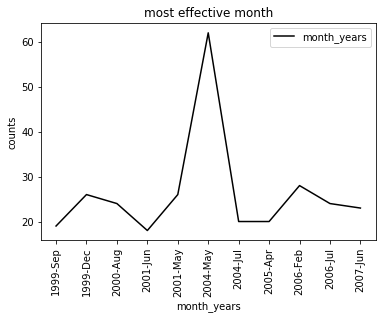

```python
a=['1999-Sep','1999-Dec','2000-Aug','2001-Jun','2001-May',
   '2004-May','2004-Jul','2005-Apr','2006-Feb','2006-Jul','2007-Jun']
b=[19,26,24,18,26,62,20,20,28,24,23]


plt.plot(a,b,'k')

plt.legend(['month_years','counts'])
plt.title('most effective month')
plt.xlabel('month_years')
plt.xticks(rotation = 90)
plt.ylabel('counts')

plt.show()
```

The infographic shows that the most active month is May of 2004, so if it recorded 62 different air movements, we note that the second month was February of 2006 if it recorded 28 different flights.

# Conclusions:

1) The great company in the aircraft industry is witnessing significant activity As the most effective year is 2006, it records 171 different flights In second place in 2001-2004, the two years recorded 170 different trips

2) We notice that the company has a clear and effective growth in the aviation industry, as the relationship recorded here is positive

3) 298 aircraft feature the 737-7H4, an average of 15% of all models In second place was the 737-3H4, with a rate of 7%.

4) The most common engine is the Turbo-Fan, as there are 1264 running on this engine The rest of the aircraft are powered by the Turbo-Jet engine.

5) The infographic shows that the most active month is May of 2004, if it recorded 62 different air movements, we note that the second month was February of 2006 if it recorded 28 different flights

# G- BOMBARDIER_INC :

is a Canadian multinational that founded in 1942 by Joseph-Armand Bombardier. It is a manufacturer of business jets, public transport vehicles, and trains, with the latter two businesses pending sale to Alstom. It was also formerly a manufacturer of commercial jets and recreational vehicles, with the latter being spun-off as Bombardier Recreational Products. Its Bombardier Aviation division is headquartered in Montreal, and Bombardier Transportation in Berlin, Germany. The company was orginally created to produce snowmobiles, but it expanded into the aviation, rail, and public transit businesses.

Bombardier manufactures several series of corporate jets, Global 7500, Global Express, Challenger 600, Challenger 300, and Learjet 70/75.

## 1) What is the most active year?

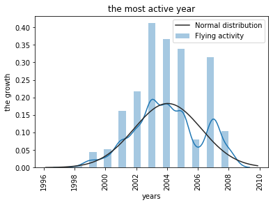

```python
from scipy.stats import norm
sns.distplot(manufacturer_BOMBARDIER_INC.years, fit=norm );
plt.legend(['Normal distribution','Flying activity'])
plt.title('the most active year')
plt.xlabel('years')
plt.xticks(rotation = 90)
plt.ylabel('the growth')
```

- The most active year is the year 2003, when 102 different flights were registered, operating 20% of all flights
- year 2004 was an excellent aviation activity, with 91 flights recorded operating 18% of all flights

## 4) What is the model most used and applied?

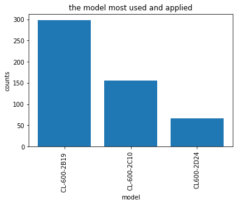

```python
x = ['CL-600-2B19 ','CL-600-2C10','CL600-2D24']
y = [298,156,66]
#تغير لون محدد في البارت شارت

#نضع c هنا
plt.bar(x,y)
plt.xlabel("model")
plt.ylabel('counts')
plt.title('the model most used and applied')
plt.xticks(rotation = 90);

plt.show()
```

The most used model is the CL-600-2B19, with 298 aircraft carrying the same model

# Conclusions:

1) The most active year is 2003, with 102 different flights recorded

2) In second place, the year 2004 constitutes an excellent flight activity, if 91 flights are recorded

3) One of the most effective months was September of 2005, if it contained 51 flights per month

4) The most used model is the CL-600-2B19, as there are 298 aircraft carrying the same model

5) One of the most active months for aircraft featuring the CL-600-2B19 model, is April of 2004, if 26 flights were recorded, also September of 2005, 17 different flights were recorded.

# Perceptions:

2) All three models, based on the statistics, are necessary

# H- EMBRAER :

is a Brazilian aerospace conglomerate that produces commercial, military, executive and agricultural aircraft[6] and provides aeronautical services. It was founded in 1969 in São José dos Campos, São Paulo, where its headquarters are located. The company is the third largest producer of civil aircraft, after Boeing and Airbus.[7]

On 26 February 2019, Embraer and Boeing announced the acquisition of an 80% share of Embraer's commercial division, which would take the name Boeing Brasil – Commercial, and market the E-Jet and E-Jet E2 series of narrow-body short-to medium-range twin-engine jet airliners.[8] The deal was canceled in April 2020 when Boeing felt that its demands could not be satisfied. Embraer alleged that Boeing was in financial trouble after being heavily affected by the reduction of demand caused by the COVID-19 pandemic and, to a lesser degree, the disasters involving flaws in its 737 MAX airplanes, led to the deal being broken.

## 3) What is the general activity of EMBRAER in air navigation traffic?

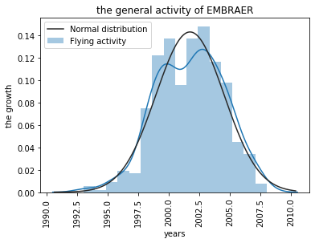

```python
sns.distplot(manufacturer_EMBRAER.years, fit=norm );
plt.legend(['Normal distribution','Flying activity'])
plt.title('the general activity of EMBRAER')
plt.xlabel('years')
plt.xticks(rotation = 90)
plt.ylabel('the growth')
```

EMBRAER's activity in each of the years 2000-2002 is generally stable, with an average of 73 to 15 flights, or approximately 13% of the company's overall activity. The most effective year is 2003, 79 trips were recorded, which is approximately 14%.

# Conclusions:

1) The first flight recorded in the data was in October 1993 of the type Corporation, and the engine type was: Turbo-Prop

4) The airline relies on most of its flights on the "EMB-145LR". Approximately 213 flights were on board aircraft of this model.

5) The most active month of the EMB-145LR is October 2000, if 27 flights all departed from the same mode, then it will follow in May 2002 if 22 flights were launched on the same model plane

6) The airline depends on the type of turbo-fan engine, if 72% of its flights are operated on aircraft operating on this type of engine

# Perceptions:

1) The company is recording a noticeable decrease in its air activity, as 4 flights were detected in 2008 and it is in the lagging places in the industrial growth of aviation.